# Noções de SQL, organização e visualização de dados usando o tidyverse

Catia Tondolo & Magno Severino

23/11/2021

## Parte 1: organização e visualização de dados usando o tidyverse

### Objetivos de aprendizagem

Ao final da aula você será capaz de

- descrever e entender o funcionamento dos principais verbos do `dplyr`,
- combinar os diferentes verbos do `dplyr` para manipular bases de dados,
- compreender o que é a gramática de gráficos,
- criar gráficos usando `ggplot2`.

Antes de iniciar, vamos instalar o pacote `tidyverse`, que é uma coleção de bibliotecas criadas para o universo de análise de dados.

```r
install.packages("tidyverse")
library(tidyverse)
```

Veja todos os pacotes disponíveis em [www.tidyverse.org](https://www.tidyverse.org/). O pacote `dplyr` faz parte do universo `tidyverse`.

### O operador pipe ( %>% ) da biblioteca `magrittr`

A função deste operar é passar o objeto do lado esquerdo como primeiro argumento da função do lado direito:

- `x %>% f(y)` é equivalente a `f(x,y)`
- `y %>% f(x,.,z)` é equivalente a `f(x,y,z)`

Atalho no teclado: `Ctrl + Shift + M`

Na prática, vamos supor que queremos somar todos os elementos do `vetor` e em seguida tirar a raiz quadrada desta soma:

```r
vetor <- c(20, 40, 60, 80, 200)

sqrt(sum(vetor))
```

```
## [1] 20
```

Usando o pipe:

```r
vetor %>% sum() %>% sqrt()
```

```
## [1] 20
```

### Transformação de Dados com `dplyr`

Os cinco principais verbos do pacote `dplyr` são:

- `select()`: seleciona colunas de um dataframe
- `filter()`: filtra linhas que satisfazem uma condição lógica
- `arrange()`: ordena as linhas de acordo com uma coluna
- `mutate()`: cria novas colunas
- `summarize()`: sumariza as informações

Todas as funções com estes verbos os funcionam de maneira similar:

1. O primeiro argumento é um data frame
2. Os próximos argumentos descrevem o que fazer com o data frame
3. O resultado é um novo data frame

### Dados

Vamos considerar a base de dados `flights` do pacote `nycflights13`, que lista todos os voos que partiram dos aeroportos da cidade de Nova York em 2013.

```r
library(nycflights13)
data(flights)
```

A primeira função que vamos ver não se encontra da lista dos principais verbos mencionada acima. Veja a documentalção da função `slice` (comando: `?slice`).

```r
flights %>%
  slice_head(n = 5)
```

| year | month | day | dep_time | sched_dep_time | dep_delay | arr_time | sched_arr_time | arr_delay | carrier | flight | tailnum | origin | dest | air_time | distance | hour | minute | time_hour |
| --- | --- | --- | --- | --- | --- | --- | --- | --- | --- | --- | --- | --- | --- | --- | --- | --- | --- | --- |
| 2013 | 1 | 1 | 517 | 515 | 2 | 830 | 819 | 11 | UA | 1545 | N14228 | EWR | IAH | 227 | 1400 | 5 | 15 | 2013-01-01 05:00:00 |
| 2013 | 1 | 1 | 533 | 529 | 4 | 850 | 830 | 20 | UA | 1714 | N24211 | LGA | IAH | 227 | 1416 | 5 | 29 | 2013-01-01 05:00:00 |
| 2013 | 1 | 1 | 542 | 540 | 2 | 923 | 850 | 33 | AA | 1141 | N619AA | JFK | MIA | 160 | 1089 | 5 | 40 | 2013-01-01 05:00:00 |
| 2013 | 1 | 1 | 544 | 545 | -1 | 1004 | 1022 | -18 | B6 | 725 | N804JB | JFK | BQN | 183 | 1576 | 5 | 45 | 2013-01-01 05:00:00 |
| 2013 | 1 | 1 | 554 | 600 | -6 | 812 | 837 | -25 | DL | 461 | N668DN | LGA | ATL | 116 | 762 | 6 | 0 | 2013-01-01 06:00:00 |

### Selecionando colunas com `select`()

Vamos selecionar quatro colunas específicas da base de dados: `carrier`, `year`, `month` e `day`.

```r
flights %>%
  select(carrier, year, month, day)
```

Podemos selecionar todas as colunas, com exceção de algumas, como por exemplo a coluna `year`.

```r
flights %>%
  select(-year)
```

`everything()` é útil para mover as colunas de lugar ao fazer uma seleção.

```r
flights %>%
  select(carrier, origin, everything())
```

Também podemos renomear uma coluna dentro do `select`.

```r
flights %>%
  select("ano" = year, month, day, ends_with("delay"))
```

### Filtrando linhas com `filter()`

Vamos obter somente os dados de voos ocorridos em 01/01/2013.

```r
flights %>%
  filter(month == 1, day == 1)
```

Abaixo, outro exemplo de filtro: voos partindo dos aeroportos JF Kennedy ou Newark com destino a Los Angeles.

```r
flights %>%
  filter(origin %in% c("JFK", "EWR"), dest == "LAX")
```

### Arranjando linhas com `arrange()`

O código a seguir arranja os dados segundo a ordem crescente da coluna `dep_delay`.

```r
flights %>%
  arrange(dep_delay)
```

Agora usando a ordem decrescente.

```r
flights %>%
  arrange(desc(dep_delay))
```

Se você fornecer mais de uma coluna, as demais colunas serão usadas sucessivamente para decidir os empates.

```r
flights %>%
  arrange(desc(month), day)
```

#### Combinando `filter()`, `select()` e `arrange()`

Vamos verificar qual a companhia aérea que teve o voo com maior atraso nos vôos entre JFK e LAX.

```r
flights %>%
  filter(origin == "JFK", dest == "LAX") %>%
  select(carrier, dep_delay, year, month, day) %>%
  arrange(desc(dep_delay)) %>%
  slice_head(n = 1)
```

A tabela `airlines`, também do pacote `nycflights13`, contém o nome completo das companhias e o respectivo código que aparece na tabela `flights`.

```r
data(airlines)
airlines %>%
  filter(carrier == "DL")
```

### Criando variáveis com `mutate()`

Vamos criar uma variável que mostre a velocidade de cada voo.

```r
flights %>%
  select(year:day, flight, distance, air_time) %>%
  mutate(speed = distance / (air_time / 60))
```

Note que você também pode se referir às variáveis que criou:

```r
flights %>%
  select(year:day, flight,  distance, air_time) %>%
  mutate(hours = air_time / 60,
         speed = distance / hours)
```

Para manter apenas as variáveis calculadas, use `transmute`().

```r
flights %>%
    transmute(hours = air_time / 60,
              speed = distance / hours)
```

Note que é equivalente a `%>% select(hours, speed)` no final do código anterior.

### Colapsando linhas com `summarise()`

Vamos calcular o atraso médio de decolagem e a quantidade total de voos.

```r
flights %>%
  filter(!is.na(dep_delay)) %>%
  summarise(mean_delay = mean(dep_delay),
            number_of_flights = n())
```

### Mudando o comportamento de alguns verbos com `group_by()`

Vamos calcular o atraso médio de decolagem e a quantidade total de voos, mas agora analisando por companhia aérea e ordenar pela companhia que apresentou o maior atraso médio.

```r
flights %>%
  filter(!is.na(dep_delay)) %>%
  group_by(carrier) %>%
  summarise(mean_delay = mean(dep_delay), number_of_flights = n()) %>%
  arrange(desc(mean_delay))
```

O código abaixo calcula, para cada destino, a distância média dos voos, o tempo de atraso médio na decolagem e o número de voos na base.

```r
flights %>%
  filter(!is.na(distance), !is.na(dep_delay)) %>%
  group_by(dest) %>%
  summarise(count = n(),
            distance = mean(distance),
            delay = mean(dep_delay))
```

## Visualização de dados com `ggplot2`

Você deve instalar e carregar o pacote `ggplot2`.

```r
# install.packages(ggplot2)
library(ggplot2)
```

O pacote `ggplot2` utiliza a gramática de gráficos. Um gráfico é um mapeamento de dados para atributos estéticos (*aesthetics*: cor, forma, tamanho), de objetos geométricos (pontos, linhas, barras). Também pode conter transformações estatísticas (*stats*) dos dados e é desenhado num sistema de coordenadas específico. Facetas podem ser utilizadas para gerar o mesmo gráfico para diferentes subconjuntos da base de dados.

Os componentes básicos de um gráfico ggplot são

- dados (*data*): conjuntos de ados a ser visualizaado no gráfico
- geometria (*geometry*): tipo de gráfico – dispersão, linhas, colunas, histograma, boxplot, etc
- estética (*aesthetics*): aspectos visuais de mapeamento de variáveis, como eixos *x* e *y* e cores.

#### Gráfico de dispersão

O código a seguir mescla processamento de dados e criação de uma visualização gráfica. O objetivo é criar um gráfico de dispersão entre dep_delay e arr_delay somente para os voos cuja origem é JFK e o destino é LAX.

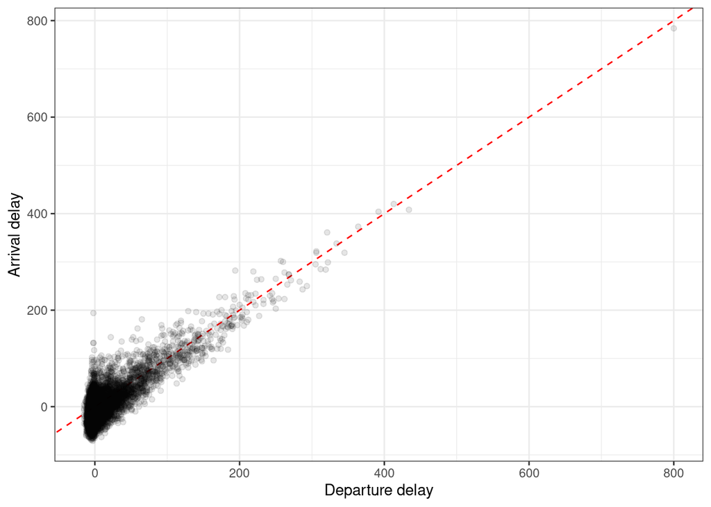

```r
flights %>%
  filter(origin == "JFK", dest == "LAX",
         !is.na(dep_delay), !is.na(arr_delay)) %>%
  ggplot(aes(x = dep_delay, y = arr_delay)) +
  geom_abline(slope = 1, intercept = 0,
              linetype = "dashed", color = "red") +
  geom_point(alpha = 0.1) +
  labs(x = "Departure delay",
       y = "Arrival delay") +
  theme_bw()
```

Uma variação deste gráfico seria considerar como origem todos os aeroportos da cidade de NYC. Então podemos adicionar uma estética de cor para diferenciar as diferentes origens.

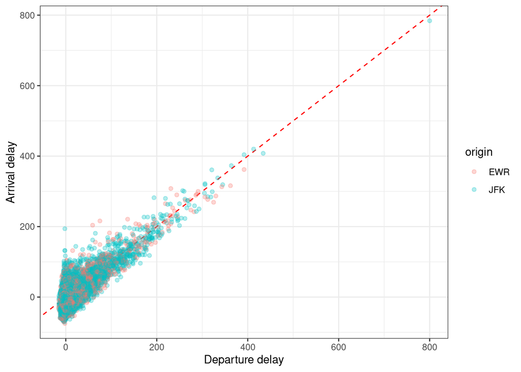

```r
flights %>%
  filter(dest == "LAX",
         !is.na(dep_delay), !is.na(arr_delay)) %>%
  ggplot(aes(x = dep_delay, y = arr_delay, color = origin)) +
  geom_abline(slope = 1, intercept = 0,
              linetype = "dashed", color = "red") +
  geom_point(alpha = 0.3) +
  labs(x = "Departure delay",
       y = "Arrival delay") +
  theme_bw()
```

Veja que a visualização não é fácil. Uma forma de melhorá-la é adicionando facetas no gráfico.

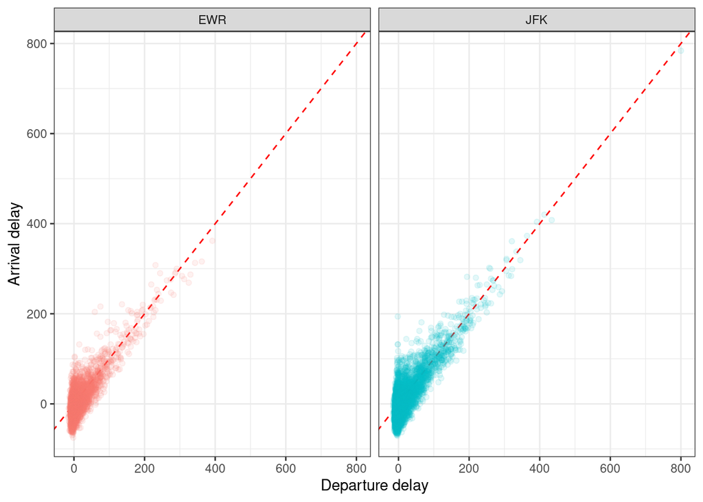

```r
flights %>%
  filter(dest == "LAX",
         !is.na(dep_delay), !is.na(arr_delay)) %>%
  ggplot(aes(x = dep_delay, y = arr_delay, color = origin)) +
  geom_abline(slope = 1, intercept = 0,
              linetype = "dashed", color = "red") +
  geom_point(alpha = 0.1) +
  facet_wrap(vars(origin)) +
  labs(x = "Departure delay",
       y = "Arrival delay") +
  theme_bw() +
  theme(legend.position = "none")
```

#### Gráfico de barras

O código abaixo faz um gráfico de barras que mostra os destinos que apresentaram os maiores atrasos médios. Para obter o nome dos aeroportos, mesclamos esses dados com a tabela `airports`.

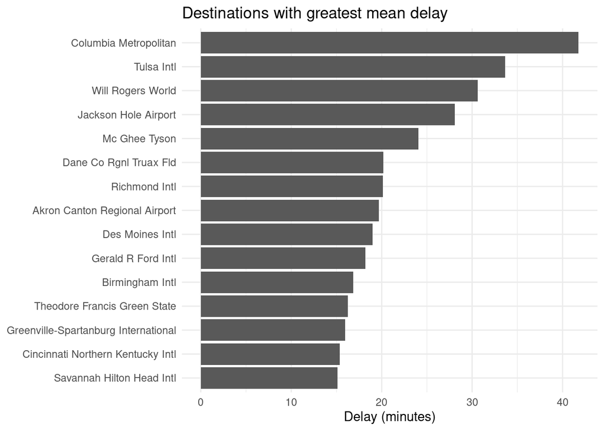

```r
flights %>%
  filter(!is.na(arr_delay)) %>%
  group_by(dest) %>%
  summarise(delay = mean(arr_delay)) %>%
  merge(airports, by.x = "dest", by.y="faa") %>%
  mutate(name = fct_reorder(name, delay)) %>%
  slice_max(delay, n = 15) %>%
  ggplot(aes(name, delay))+
  geom_col()+
  coord_flip()+
  labs(x = NULL,
       y = "Delay (minutes)",
       title = "Destinations with greatest mean delay")+
  theme_minimal()
```

#### Gráfico de linhas

O trecho de código abaixo obtem os três destinos com mais voos partindo de NYC em 2013, sumariza o número de voos por mês e faz um gráfico de linhas mostrando a série história ao longo do ano para cada um dos destinos.

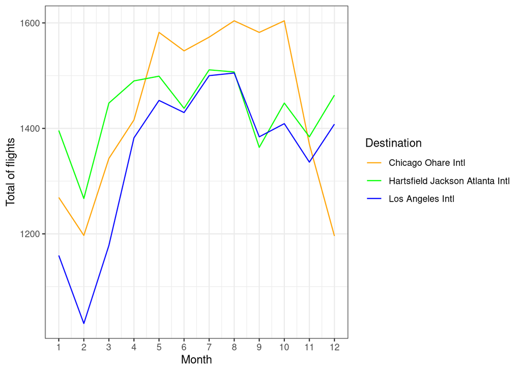

```r
top_dest <- flights %>%
  group_by(dest) %>%
  summarise(n = n()) %>%
  slice_max(n, n = 3) %>%
  select(dest) %>%
  pull()

flights %>%
  filter(dest %in% top_dest) %>%
  group_by(dest, month) %>%
  summarise(total = n()) %>%
  inner_join(airports, by = c("dest" = "faa")) %>%
  ggplot(aes(month, total, color = name)) +
  geom_line()+
  scale_x_continuous(breaks = 1:12) +
  scale_color_manual(values = c("orange", "green", "blue")) +
  labs(x = "Month",
       y = "Total of flights",
       color = "Destination") +
  theme_bw()
```

A depender da história que se quer contar com os dados, podemos editar as configurações de visualização do gráfico.

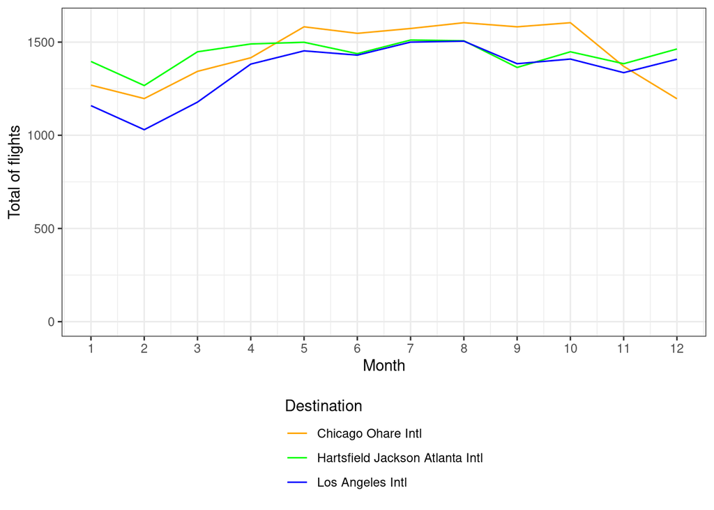

```r
flights %>%
  filter(dest %in% top_dest) %>%
  group_by(dest, month) %>%
  summarise(total = n()) %>%
  inner_join(airports, by = c("dest" = "faa")) %>%
  ggplot(aes(month, total, color = name)) +
  geom_line()+
  scale_x_continuous(breaks = 1:12) +
  scale_color_manual(values = c("orange", "green", "blue")) +
  ylim(0, NA) +
  labs(x = "Month",
       y = "Total of flights",
       color = "Destination") +
  theme_bw()+
  theme(legend.position = "bottom",
        legend.direction = "vertical")
```

#### Boxplots

O código abaixo obtem os dois destinos mais frequentes partindo de NYC, e as companhias aéreas que voaram pelo menos 100 vezes para estes destinos. Ao construir o gráfico, fazemos a junção dos dados em `flights` com as tabelas `airlines` e `airports` para obter o nome completo das companhias aéreas e o nome completo dos aeroportos, respectivamente.

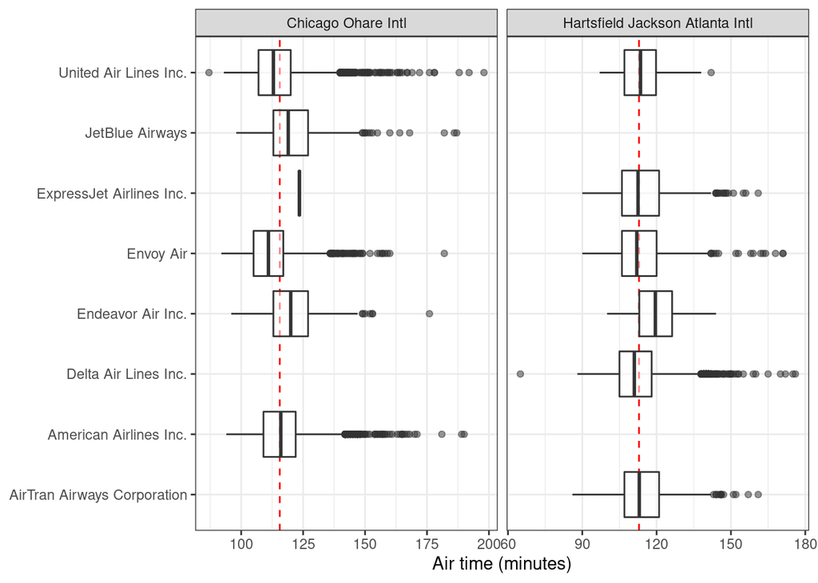

```r
# top 2 destinos mais voados
top_dest <- flights %>%
  group_by(dest) %>%
  summarise(n = n()) %>%
  slice_max(n, n = 2) %>%
  select(dest) %>%
  pull()

# obter as cias que voaram pelo menos 100 vezes nesses trechos
cias <- flights %>%
  filter(dest %in% top_dest) %>%
  group_by(carrier, dest) %>%
  summarise(n = n()) %>%
  filter(n > 100) %>%
  select(carrier) %>%
  pull() %>%
  unique()

# cria o gráfico
flights %>%
  filter(!is.na(air_time), carrier %in% cias,
         dest %in% top_dest) %>%
  inner_join(airlines, by = c("carrier" = "carrier")) %>%
  inner_join(airports %>%
               select(airport_name = name, faa),
             by = c("dest" = "faa")) %>%
  ggplot(aes(x = name, y = air_time)) +
  facet_wrap(vars(airport_name), scales = "free_x") +
  geom_hline(aes(yintercept = mean),
              data = flights %>%
               filter(!is.na(air_time), carrier %in% cias,
                      dest %in% top_dest) %>%
               group_by(dest) %>%
               summarise(mean = mean(air_time)) %>%
               inner_join(airports %>%
                            select(airport_name = name, faa),
                          by = c("dest" = "faa")),
             linetype = "dashed", color = "red") +
  geom_boxplot(alpha = 0.5) +
  coord_flip() +
  labs(x = NULL, y = "Air time (minutes)") +
  theme_bw()
```

### Código R

O arquivo com o código R completo feito durante a aula pode ser acessado [aqui](http://www.ime.usp.br/~magno/slides/codigo_parte1.R).

### Referências

1. Wickham, H. [Tidy data](https://www.jstatsoft.org/article/view/v059i10). Journal of statistical software, v. 59, n. 1, p. 1-23, 2014.
2. Wickham, Hadley. [A layered grammar of graphics](https://www.tandfonline.com/doi/abs/10.1198/jcgs.2009.07098?casa_token=Pa0kA3l4-6cAAAAA:sj-vJ-VGQ4f_YiU2C1to0qEZJ5d3x2ij_UekBxuW5y-Wpb6T7-MvQDzqhQPh514Ho9xMSkpvSSL2fAM). Journal of Computational and Graphical Statistics 19.1 (2010): 3-28.
3. Livro [R for Data Science](https://r4ds.had.co.nz/) Wickham, H. and Grolemund, G. 2017.